# ROCpAUC: Partial Area Indexes for ROC Curve Analysis

## 3.1 Demo

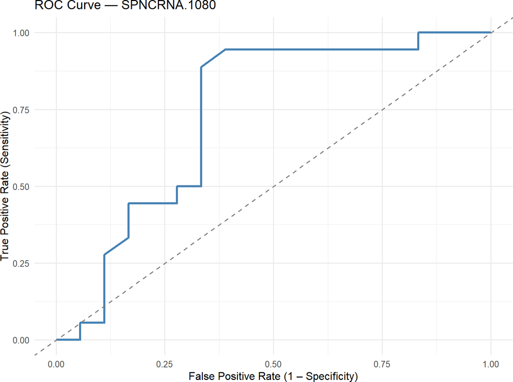

| FPR | TPR |
| --- | --- |
| 0.00000000 | 0.00000000 |
| 0.05555556 | 0.00000000 |
| 0.05555556 | 0.05555556 |
| 0.11111111 | 0.05555556 |
| 0.11111111 | 0.11111111 |
| 0.11111111 | 0.16666667 |
| 0.11111111 | 0.22222222 |
| 0.11111111 | 0.27777778 |
| 0.16666667 | 0.33333333 |
| 0.16666667 | 0.38888889 |

[output cut: 20 more lines]

```r
# Input type 1: plain data.frame
# Plot the empirical ROC curve for the first gene using the pre-built Sp data.frame
pointsCurve(Sp[, 1], as.numeric(Sp[, 2]),
            plot  = TRUE,
            label = colnames(Sp)[2])
```

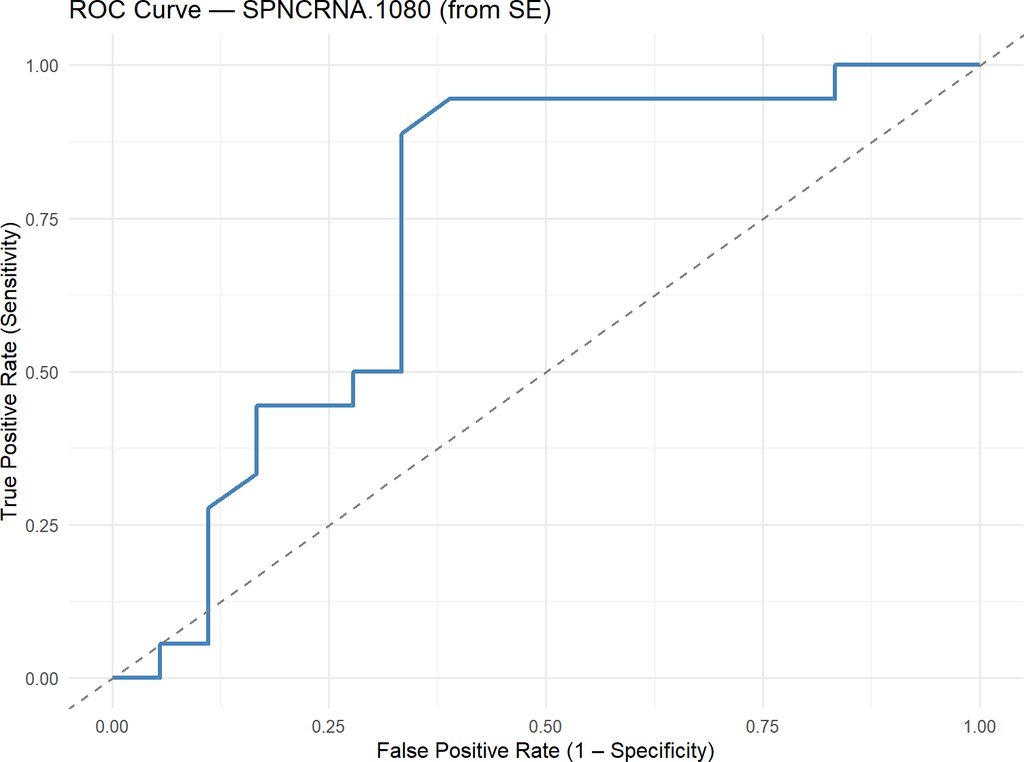

| FPR | TPR |
| --- | --- |
| 0.00000000 | 0.00000000 |
| 0.05555556 | 0.00000000 |
| 0.05555556 | 0.05555556 |
| 0.11111111 | 0.05555556 |
| 0.11111111 | 0.11111111 |
| 0.11111111 | 0.16666667 |
| 0.11111111 | 0.22222222 |
| 0.11111111 | 0.27777778 |
| 0.16666667 | 0.33333333 |
| 0.16666667 | 0.38888889 |

[output cut: 20 more lines]

```r
# Input type 2: vectors extracted directly from a SummarizedExperiment
# Extract outcome and predictor from the SE object and pass them as vectors
outcome = SummarizedExperiment::colData(fission)$strain
expr    = SummarizedExperiment::assay(fission)["SPNCRNA.1080", ]

pointsCurve(as.numeric(outcome), as.numeric(expr),
            plot  = TRUE,
            label = "SPNCRNA.1080 (from SE)")
```

# 4 Point-Estimate Functions

## 4.1 pAUC — Raw Partial Area Under the ROC Curve

Returns the trapezoidal pAUC for a given FPR or TPR interval without any scaling. Useful as a diagnostic building block or for direct comparison with software that reports raw pAUC values. All four scaled indexes (MCpAUC,TpAUC, NpAUC, FpAUC) are derived from this quantity

$$AUC = \int_0^1 TPR(FPR) \, d(FPR)$$

$$pAUC_{(t_1, t_2)} = \int_{t_1}^{t_2} TPR(FPR) \, d(FPR)$$

### 4.1.1 Demo — pAUC

```r
# Input type 1: SummarizedExperiment, FPR domain [0, 0.25]
pAUC(fission, low.value = 0, up.value = 0.25,
     axis = "x", selection = genes_of_interest, variable = "strain")
```

| Variable | pAUC |
| --- | --- |
| SPNCRNA.1080 | 0.05709877 |
| SPAC186.08c | 0.11921296 |
| SPNCRNA.1420 | 0.14737654 |
| SPCC70.08c | 0.16820988 |
| SPAC212.04c | 0.18055556 |

```r
# Input type 2: SummarizedExperiment, TPR domain [0.9, 1]
pAUC(fission, low.value = 0.9, up.value = 1,
     axis = "y", selection = genes_of_interest, variable = "strain")
```

| Variable | pAUC |
| --- | --- |
| SPNCRNA.1080 | 0.03740741 |
| SPAC186.08c | 0.04913580 |
| SPNCRNA.1420 | 0.06154321 |
| SPCC70.08c | 0.06358025 |
| SPAC212.04c | 0.04580247 |

```r
# Input type 3: plain data.frame, FPR domain
pAUC(Sp, low.value = 0, up.value = 0.25, axis = "x")
```

| Variable | pAUC |
| --- | --- |
| SPNCRNA.1080 | 0.05709877 |
| SPAC186.08c | 0.11921296 |
| SPNCRNA.1420 | 0.14737654 |
| SPCC70.08c | 0.16820988 |
| SPAC212.04c | 0.18055556 |

## 4.2 MCpAUC — McClish Standardised pAUC

The **MCpAUC** index (McClish, 1989) rescales the raw partial area to $[0.5, 1]$ using the diagonal as the minimum reference. Defined only for *proper* ROC curves (above the diagonal throughout the region of interest):

$$\widetilde{A}_{(t_1,t_2)} = \frac{1}{2}\!\left(1 + \frac{A_{(t_1,t_2)} - A^{\min}_{(t_1,t_2)}}{A^{\max}_{(t_1,t_2)} - A^{\min}_{(t_1,t_2)}}\right)$$

### 4.2.1 Demo — MCpAUC

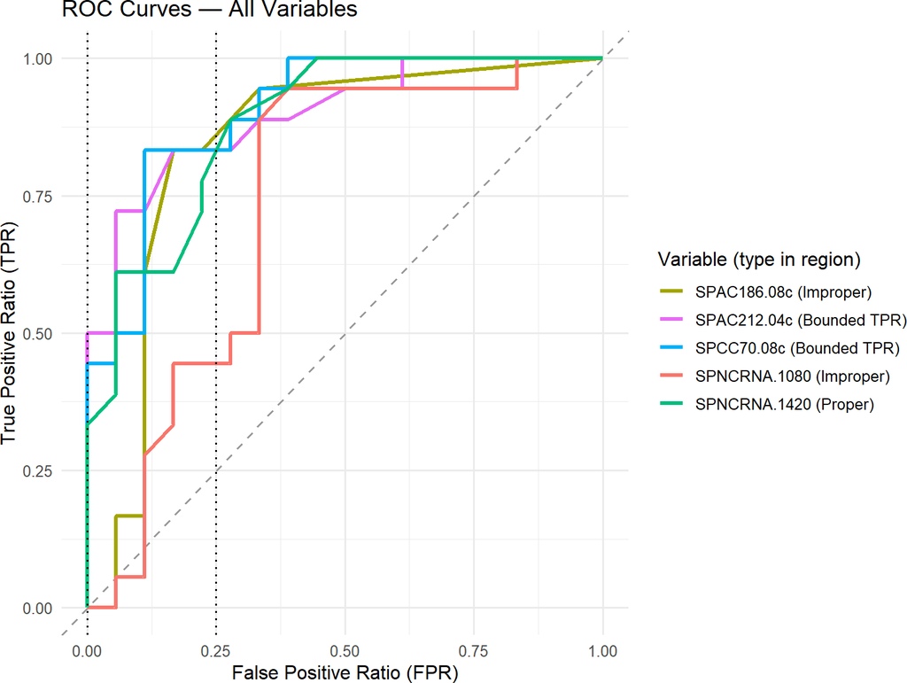

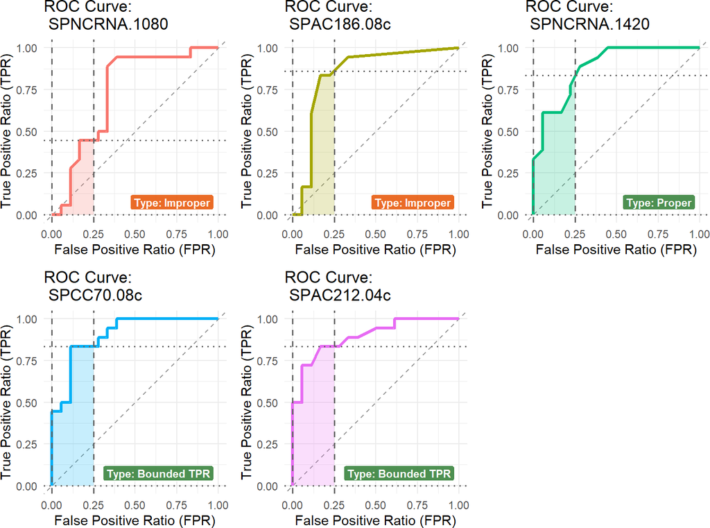

```r
# Input type 1: SummarizedExperiment → Output: tibble (with plots)
res_MC = MCpAUC(
  fission,
  low.value = 0, up.value = 0.25,
  selection = genes_of_interest, variable = "strain",
  plot = TRUE, plot_type = "both", plots_per_page = 5
)
```

```r
res_MC
```

| Variable | MCpAUC | pAUC |
| --- | --- | --- |
| SPNCRNA.1080 | NA | 0.05709877 |
| SPAC186.08c | NA | 0.11921296 |
| SPNCRNA.1420 | 0.7654321 | 0.14737654 |
| SPCC70.08c | 0.8130511 | 0.16820988 |
| SPAC212.04c | 0.8412698 | 0.18055556 |

```r
# Input type 2: SummarizedExperiment → Output: SummarizedExperiment
se_MC = MCpAUC(
  fission,
  low.value = 0, up.value = 0.25,
  selection = genes_of_interest, variable = "strain",
  output_as_SE = TRUE
)
assay(se_MC)
```

```
#>        SPNCRNA.1080 SPAC186.08c SPNCRNA.1420 SPCC70.08c SPAC212.04c
#> MCpAUC           NA          NA    0.7654321  0.8130511   0.8412698
#> pAUC     0.05709877    0.119213    0.1473765  0.1682099   0.1805556
```

```r
# Input type 3: plain data.frame → Output: tibble
MCpAUC(Sp, low.value = 0, up.value = 0.25)
```

| Variable | MCpAUC | pAUC |
| --- | --- | --- |
| SPNCRNA.1080 | NA | 0.05709877 |
| SPAC186.08c | NA | 0.11921296 |
| SPNCRNA.1420 | 0.7654321 | 0.14737654 |
| SPCC70.08c | 0.8130511 | 0.16820988 |
| SPAC212.04c | 0.8412698 | 0.18055556 |

## 4.3 TpAUC — Tighter Partial Area Index

The **TpAUC** (Vivo *et al.*, 2018) uses tighter bounds derived from the actual TPR values at the interval endpoints, making it valid for both proper and improper ROC curves and sensitive to crossing curves with equal raw pAUC:

$$A^*_{(t_1,t_2)} = \frac{1}{2}\!\left(1 + \frac{A_{(t_1,t_2)} - A^*_{\min}}{A^*_{\max} - A^*_{\min}}\right)$$

### 4.3.1 Demo — TpAUC

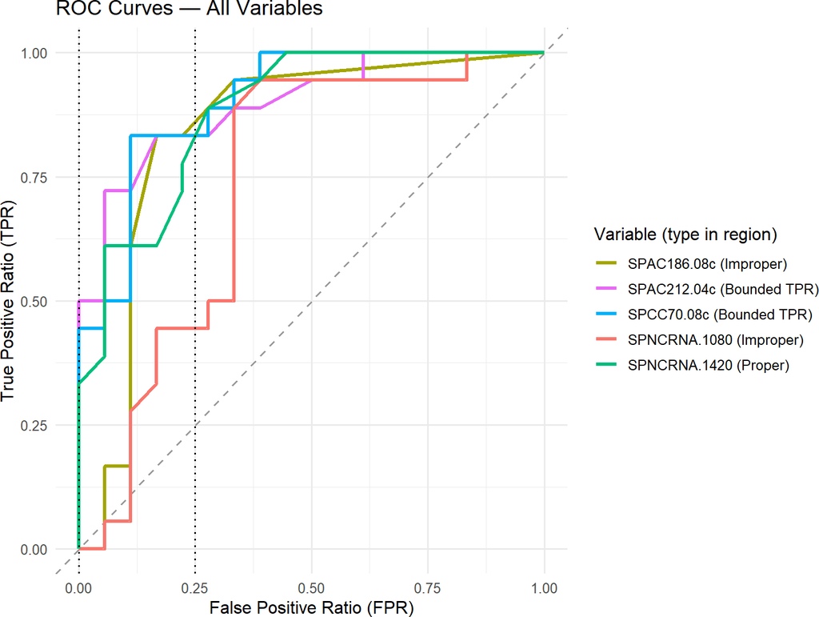

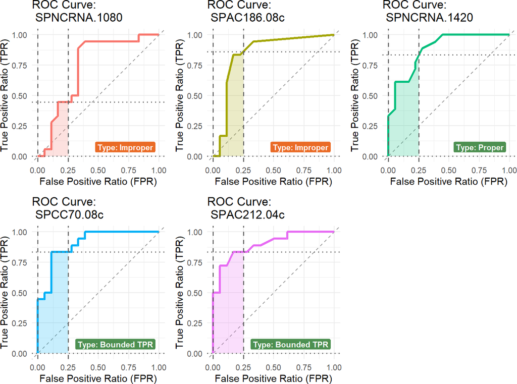

```r
# Input type 1: SummarizedExperiment → Output: tibble (with plots)
res_Tp = TpAUC(
  fission,
  low.value = 0, up.value = 0.25,
  selection = genes_of_interest, variable = "strain",
  plot = TRUE, plot_type = "both", plots_per_page = 5
)
```

```r
res_Tp
```

| Variable | TpAUC | pAUC |
| --- | --- | --- |
| SPNCRNA.1080 | 0.7569444 | 0.05709877 |
| SPAC186.08c | 0.7768817 | 0.11921296 |
| SPNCRNA.1420 | 0.8278867 | 0.14737654 |
| SPCC70.08c | 0.8074074 | 0.16820988 |
| SPAC212.04c | 0.8666667 | 0.18055556 |

```r
# Input type 2: SummarizedExperiment → Output: SummarizedExperiment
se_Tp = TpAUC(
  fission,
  low.value = 0, up.value = 0.25,
  selection = genes_of_interest, variable = "strain",
  output_as_SE = TRUE
)
assay(se_Tp)
```

```
#>       SPNCRNA.1080 SPAC186.08c SPNCRNA.1420 SPCC70.08c SPAC212.04c
#> TpAUC   0.75694444   0.7768817    0.8278867  0.8074074   0.8666667
#> pAUC    0.05709877   0.1192130    0.1473765  0.1682099   0.1805556
```

```r
# Input type 3: plain data.frame → Output: tibble
TpAUC(Sp, low.value = 0, up.value = 0.25)
```

| Variable | TpAUC | pAUC |
| --- | --- | --- |
| SPNCRNA.1080 | 0.7569444 | 0.05709877 |
| SPAC186.08c | 0.7768817 | 0.11921296 |
| SPNCRNA.1420 | 0.8278867 | 0.14737654 |
| SPCC70.08c | 0.8074074 | 0.16820988 |
| SPAC212.04c | 0.8666667 | 0.18055556 |

## 4.4 NpAUC — Normalised pAUC (High-Sensitivity Domain)

**NpAUC** (Jiang *et al.*, 1996) summarises performance above a minimum sensitivity $\text{TPR}_0$ by dividing the horizontal-band pAUC by the width of that band:

$$N\widehat{pAUC}_{\text{TPR}_0} = \frac{A_{\text{TPR}_0}}{1 - \text{TPR}_0}$$

Valid only when the NLR is bounded; returns `NA` otherwise.

### 4.4.1 Demo — NpAUC

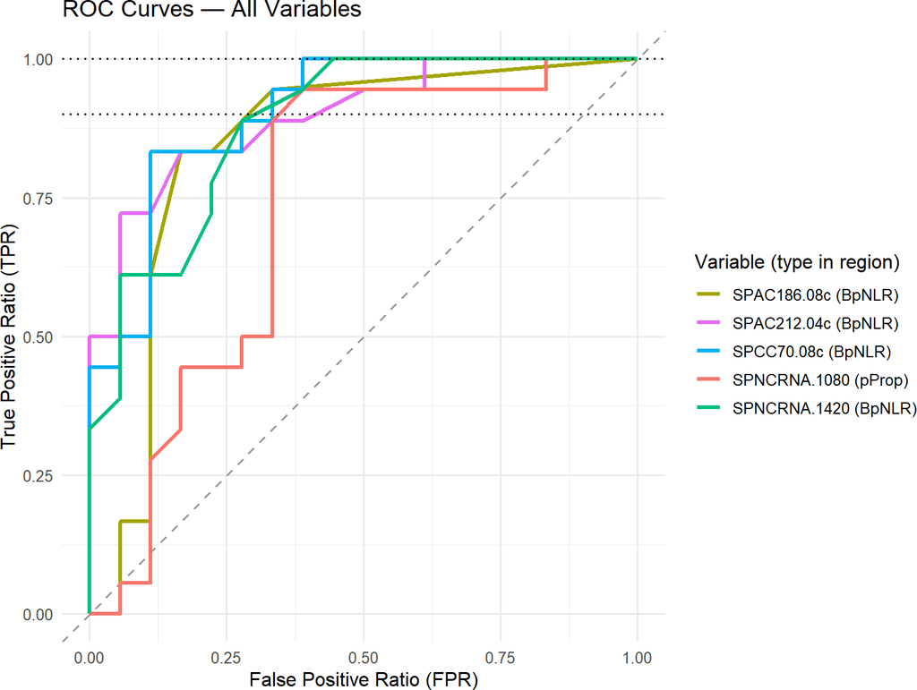

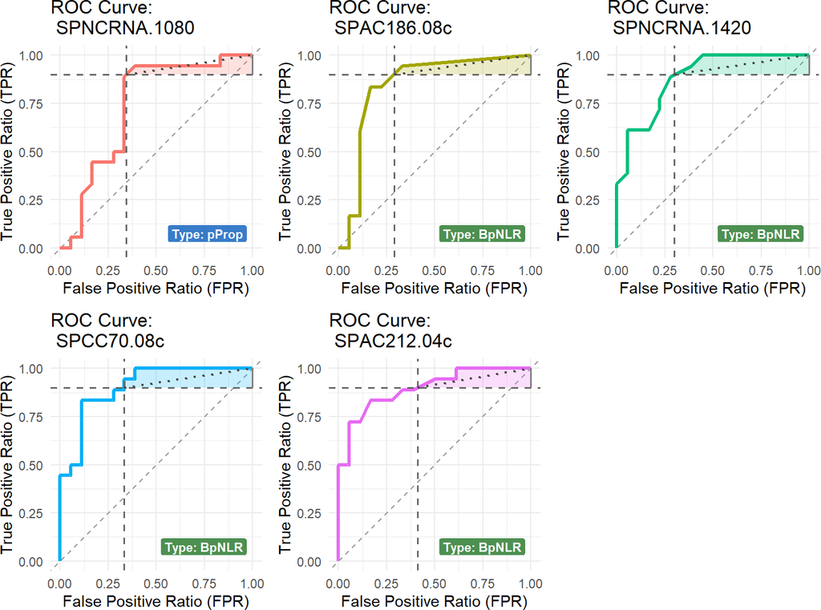

```r
# Input type 1: SummarizedExperiment → Output: tibble (with plots)
res_Np = NpAUC(
  fission,
  low.value = 0.9, up.value = 1,
  selection = genes_of_interest, variable = "strain",
  plot = TRUE, plot_type = "both", plots_per_page = 5
)
```

```r
res_Np
```

| Variable | NpAUC | pAUC |
| --- | --- | --- |
| SPNCRNA.1080 | NA | 0.03740741 |
| SPAC186.08c | 0.4913580 | 0.04913580 |
| SPNCRNA.1420 | 0.6154321 | 0.06154321 |
| SPCC70.08c | 0.6358025 | 0.06358025 |
| SPAC212.04c | 0.4580247 | 0.04580247 |

```r
# Input type 2: SummarizedExperiment → Output: SummarizedExperiment
se_Np = NpAUC(
  fission,
  low.value = 0.9, up.value = 1,
  selection = genes_of_interest, variable = "strain",
  output_as_SE = TRUE
)
assay(se_Np)
```

```
#>       SPNCRNA.1080 SPAC186.08c SPNCRNA.1420 SPCC70.08c SPAC212.04c
#> NpAUC           NA   0.4913580   0.61543210 0.63580247  0.45802469
#> pAUC    0.03740741   0.0491358   0.06154321 0.06358025  0.04580247
```

```r
# Input type 3: plain data.frame → Output: tibble
NpAUC(Sp, low.value = 0.9, up.value = 1)
```

| Variable | NpAUC | pAUC |
| --- | --- | --- |
| SPNCRNA.1080 | NA | 0.03740741 |
| SPAC186.08c | 0.4913580 | 0.04913580 |
| SPNCRNA.1420 | 0.6154321 | 0.06154321 |
| SPCC70.08c | 0.6358025 | 0.06358025 |
| SPAC212.04c | 0.4580247 | 0.04580247 |

## 4.5 FpAUC — Fitted Partial Area Index

**FpAUC** (Franco & Vivo, 2021) extends NpAUC using tighter NLR-based bounds valid for *any* ROC curve shape. Always lies in $[0.5, 1]$ and distinguishes crossing curves with equal raw pAUC.

| Case | NLR condition | FpAUC formula |
| --- | --- | --- |
| **Bounded** | $\text{NLR}(x) \leq \text{NLR}_0$ | $A_{TPR_0} \,/\, [(1-\text{FPR}_0)(1-\text{TPR}_0)]$ |
| **Partially proper** | $\text{NLR}(x) \leq 1$ | $[A_{TPR_0} + (1-\text{TPR}_0)(1-\text{FPR}_0)] \,/\, [2(1-\text{FPR}_0)(1-\text{TPR}_0)]$ |
| **Improper** | Some $\text{NLR}(x) > 1$ | $[A_{TPR_0} + (1+\text{TPR}_0)(\text{TPR}_0-\text{FPR}_0)] \,/\, [(1+\text{TPR}_0-2\text{FPR}_0)(1-\text{TPR}_0)]$ |

### 4.5.1 Demo — FpAUC

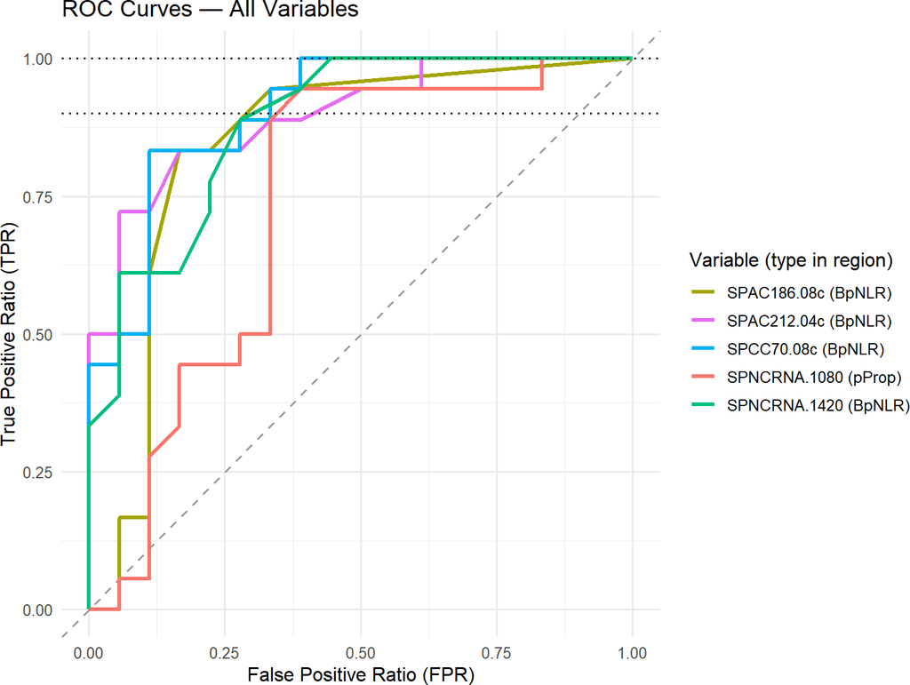

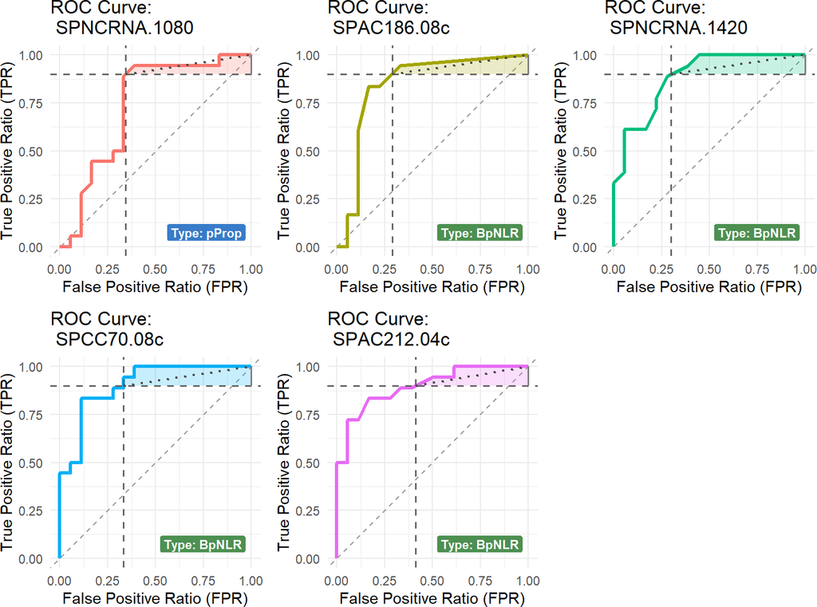

```r
# Input type 1: SummarizedExperiment → Output: tibble (with plots)
res_Fp = FpAUC(
  fission,
  low.value = 0.9, up.value = 1,
  selection = genes_of_interest, variable = "strain",
  plot = TRUE, plot_type = "both", plots_per_page = 5
)
```

```r
res_Fp
```

| Variable | FpAUC | pAUC |
| --- | --- | --- |
| SPNCRNA.1080 | 0.7675841 | 0.03740741 |
| SPAC186.08c | 0.6909722 | 0.04913580 |
| SPNCRNA.1420 | 0.8791887 | 0.06154321 |
| SPCC70.08c | 0.9537037 | 0.06358025 |
| SPAC212.04c | 0.7777778 | 0.04580247 |

```r
# Input type 2: SummarizedExperiment → Output: SummarizedExperiment
se_Fp = FpAUC(
  fission,
  low.value = 0.9, up.value = 1,
  selection = genes_of_interest, variable = "strain",
  output_as_SE = TRUE
)
assay(se_Fp)
```

```
#>       SPNCRNA.1080 SPAC186.08c SPNCRNA.1420 SPCC70.08c SPAC212.04c
#> FpAUC   0.76758410   0.6909722   0.87918871 0.95370370  0.77777778
#> pAUC    0.03740741   0.0491358   0.06154321 0.06358025  0.04580247
```

```r
# Input type 3: plain data.frame → Output: tibble
FpAUC(Sp, low.value = 0.9, up.value = 1)
```

| Variable | FpAUC | pAUC |
| --- | --- | --- |
| SPNCRNA.1080 | 0.7675841 | 0.03740741 |
| SPAC186.08c | 0.6909722 | 0.04913580 |
| SPNCRNA.1420 | 0.8791887 | 0.06154321 |
| SPCC70.08c | 0.9537037 | 0.06358025 |
| SPAC212.04c | 0.7777778 | 0.04580247 |

## 4.6 allIndices — All Four Indexes in One Call

### 4.6.1 Demo — allIndices

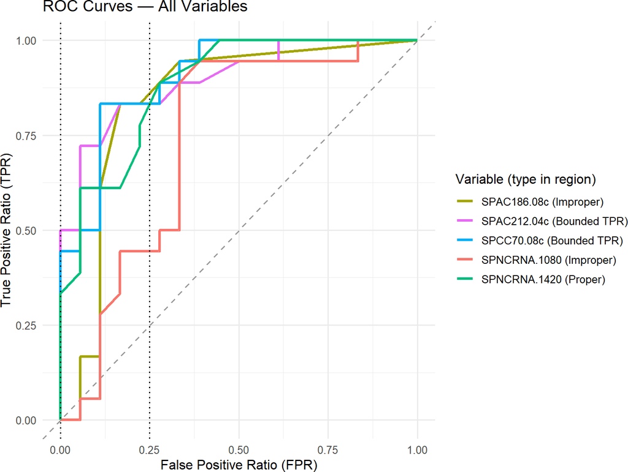

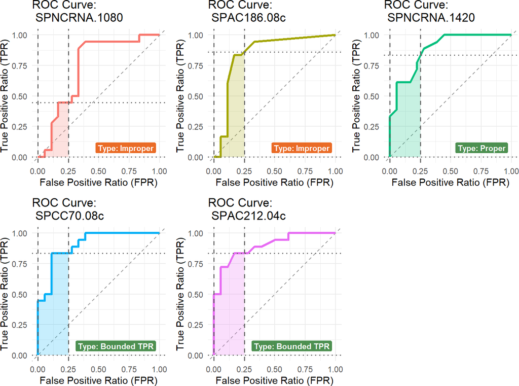

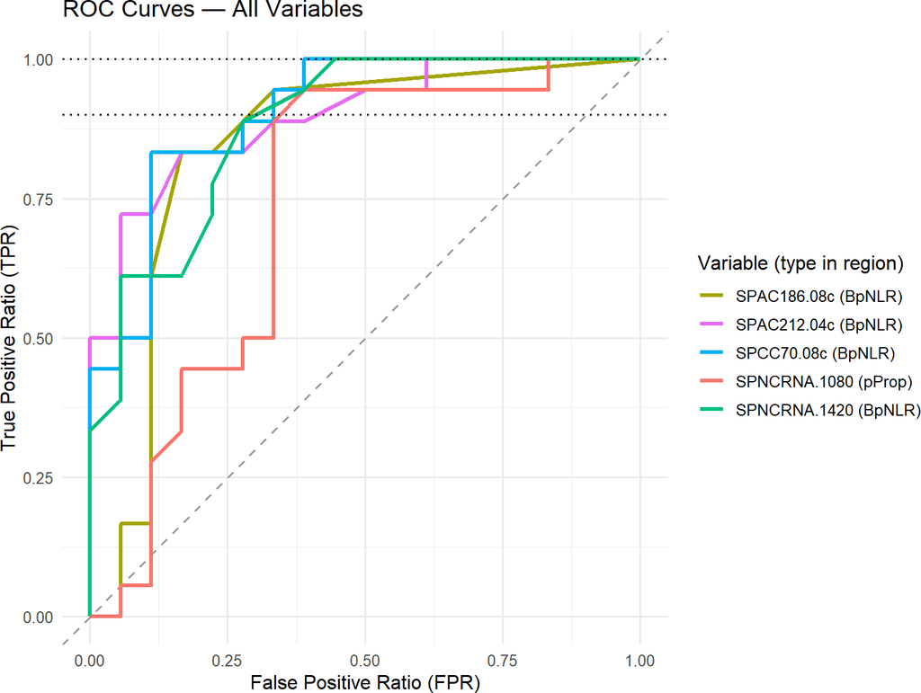

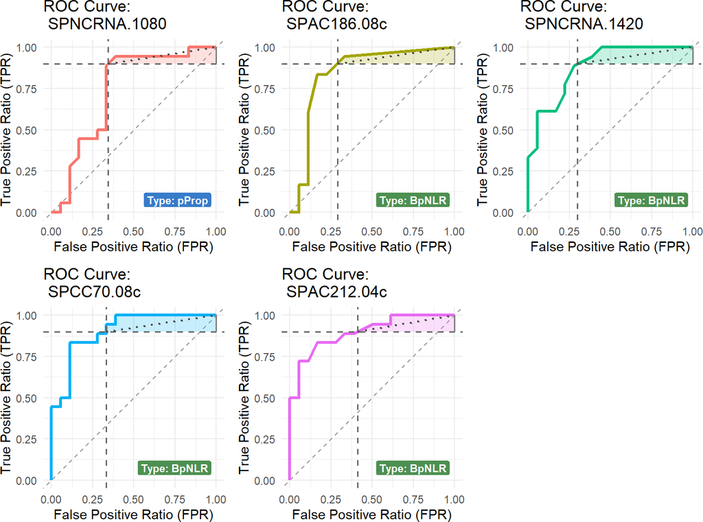

| Variable | pAUC_FPR | MCpAUC | TpAUC | pAUC_TPR | NpAUC | FpAUC |
| --- | --- | --- | --- | --- | --- | --- |
| SPNCRNA.1080 | 0.05709877 | NA | 0.7569444 | 0.03740741 | NA | 0.7675841 |
| SPAC186.08c | 0.11921296 | NA | 0.7768817 | 0.04913580 | 0.4913580 | 0.6909722 |
| SPNCRNA.1420 | 0.14737654 | 0.7654321 | 0.8278867 | 0.06154321 | 0.6154321 | 0.8791887 |
| SPCC70.08c | 0.16820988 | 0.8130511 | 0.8074074 | 0.06358025 | 0.6358025 | 0.9537037 |
| SPAC212.04c | 0.18055556 | 0.8412698 | 0.8666667 | 0.04580247 | 0.4580247 | 0.7777778 |

```r
# Input type 1: SummarizedExperiment → Output: tibble (with plots)
allIndices(
  fission,
  fpr.low = 0, fpr.up = 0.25,
  tpr.low = 0.9, tpr.up = 1,
  selection = genes_of_interest, variable = "strain",
  plot = TRUE, plot_type = "both", plots_per_page = 5
)
```

```r
# Input type 2: plain data.frame → Output: tibble
allIndices(
  Sp,
  fpr.low = 0, fpr.up = 0.25,
  tpr.low = 0.9, tpr.up = 1
)
```

| Variable | pAUC_FPR | MCpAUC | TpAUC | pAUC_TPR | NpAUC | FpAUC |
| --- | --- | --- | --- | --- | --- | --- |
| SPNCRNA.1080 | 0.05709877 | NA | 0.7569444 | 0.03740741 | NA | 0.7675841 |
| SPAC186.08c | 0.11921296 | NA | 0.7768817 | 0.04913580 | 0.4913580 | 0.6909722 |
| SPNCRNA.1420 | 0.14737654 | 0.7654321 | 0.8278867 | 0.06154321 | 0.6154321 | 0.8791887 |
| SPCC70.08c | 0.16820988 | 0.8130511 | 0.8074074 | 0.06358025 | 0.6358025 | 0.9537037 |
| SPAC212.04c | 0.18055556 | 0.8412698 | 0.8666667 | 0.04580247 | 0.4580247 | 0.7777778 |

# 5 Bootstrap Confidence Interval Functions

## 5.1 MCpAUCboot

Estimates confidence intervals for the McClish standardised pAUC (MCpAUC) via nonparametric bootstrap resampling. Variables for which MCpAUC is undefined on the original sample (improper ROC curves) are automatically skipped and return NA in all output columns.

### 5.1.1 Demo — MCpAUCboot

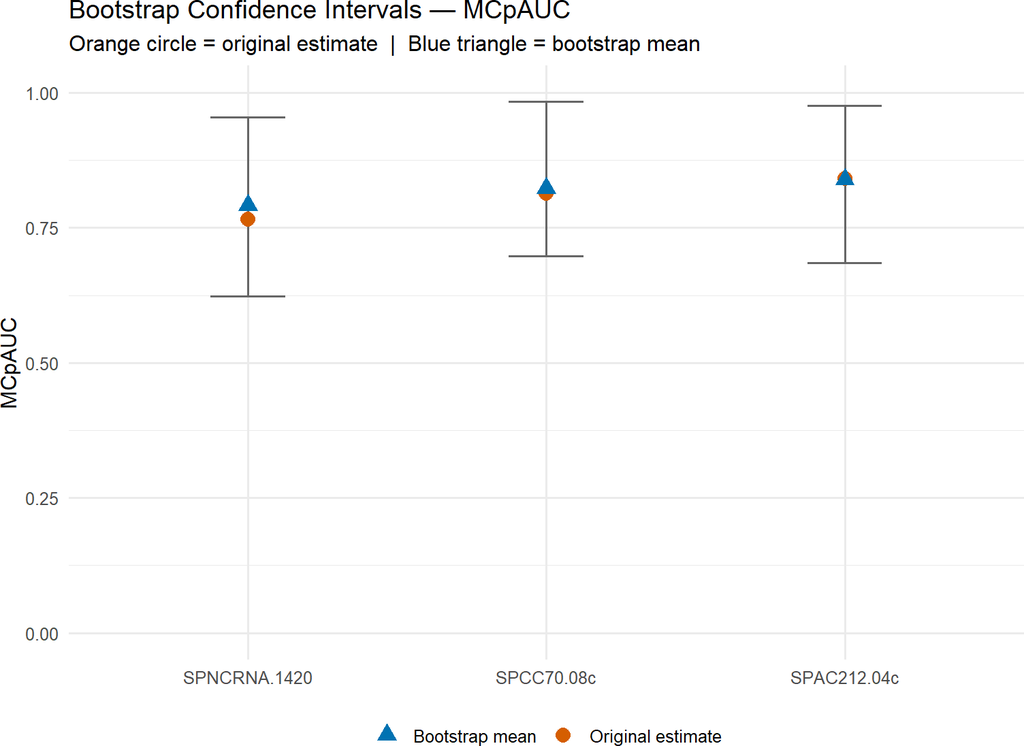

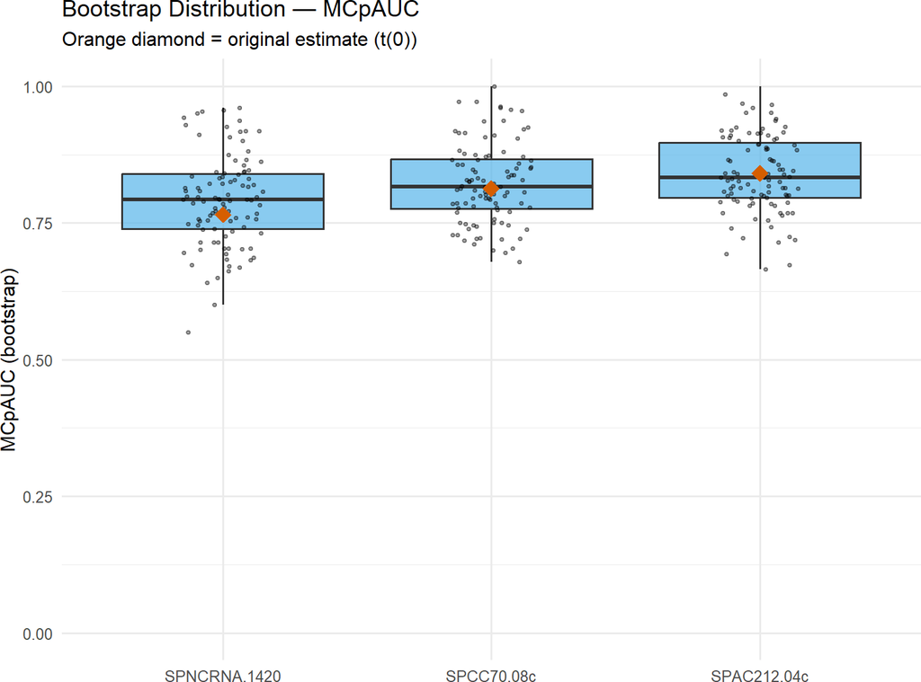

```r
# Input type 1: SummarizedExperiment → Output: tibble (with diagnostic plots)
boot_MC = MCpAUCboot(
  fission,
  low.value = 0, up.value = 0.25,
  selection = genes_of_interest, variable = "strain",
  r = 100, plot = TRUE, plot_type = "both"
)
```

```r
boot_MC
```

| Variable | MCpAUC | bias | sd | lwr | upr |
| --- | --- | --- | --- | --- | --- |
| SPNCRNA.1080 | NA | NA | NA | NA | NA |
| SPAC186.08c | NA | NA | NA | NA | NA |
| SPNCRNA.1420 | 0.7654321 | 0.025943129 | 0.08324908 | 0.6231388 | 0.9548236 |
| SPCC70.08c | 0.8130511 | 0.010523509 | 0.07414826 | 0.6979376 | 0.9839532 |
| SPAC212.04c | 0.8412698 | -0.001513627 | 0.07050750 | 0.6846103 | 0.9758856 |

```r
# Input type 2: SummarizedExperiment → Output: SummarizedExperiment
boot_MC_se = MCpAUCboot(
  fission,
  low.value = 0, up.value = 0.25,
  selection = genes_of_interest, variable = "strain",
  r = 100, output_as_SE = TRUE
)
assay(boot_MC_se)
```

```
#>        SPNCRNA.1080 SPAC186.08c SPNCRNA.1420 SPCC70.08c SPAC212.04c
#> MCpAUC           NA          NA   0.76543210 0.81305115 0.841269841
#> bias             NA          NA   0.01954788 0.01243064 0.001283905
#> sd               NA          NA   0.07976625 0.07268290 0.059447815
#> lwr              NA          NA   0.61279581 0.65596078 0.696850151
#> upr              NA          NA   0.97218003 0.95763390 0.953672030
```

```r
# Input type 3: plain data.frame → Output: tibble
MCpAUCboot(Sp, low.value = 0, up.value = 0.25, r = 100)
```

| Variable | MCpAUC | bias | sd | lwr | upr |
| --- | --- | --- | --- | --- | --- |
| SPNCRNA.1080 | NA | NA | NA | NA | NA |
| SPAC186.08c | NA | NA | NA | NA | NA |
| SPNCRNA.1420 | 0.7654321 | 0.023167761 | 0.08157525 | 0.6221614 | 0.9290474 |
| SPCC70.08c | 0.8130511 | 0.010686713 | 0.08147552 | 0.6049485 | 0.9737994 |
| SPAC212.04c | 0.8412698 | 0.004000304 | 0.06663372 | 0.7240002 | 0.9783870 |

## 5.2 TpAUCboot

Estimates confidence intervals for the tighter partial area index (TpAUC) via nonparametric bootstrap resampling. Because TpAUC is valid for any ROC curve shape, no variables are skipped (no NA from shape conditions).

### 5.2.1 Demo — TpAUCboot

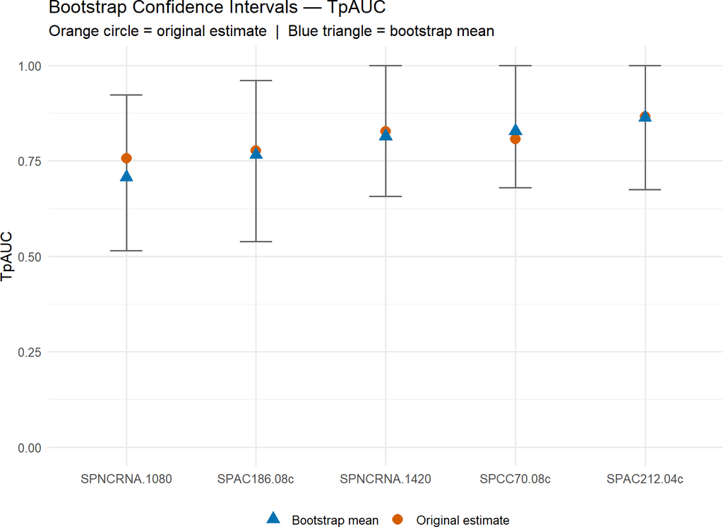

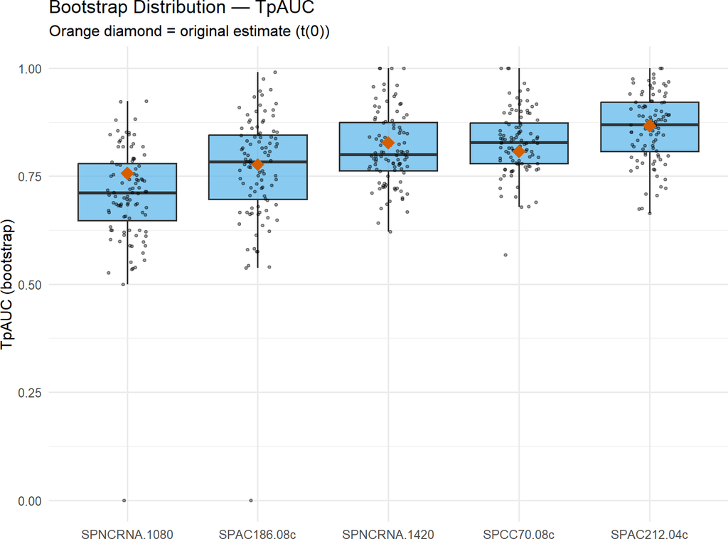

```r
# Input type 1: SummarizedExperiment → Output: tibble (with diagnostic plots)
boot_Tp = TpAUCboot(
  fission,
  low.value = 0, up.value = 0.25,
  selection = genes_of_interest, variable = "strain",
  r = 100, plot = TRUE, plot_type = "both"
)
```

```r
boot_Tp
```

| Variable | TpAUC | bias | sd | lwr | upr |
| --- | --- | --- | --- | --- | --- |
| SPNCRNA.1080 | 0.7569444 | -0.049638141 | 0.12107375 | 0.5153572 | 0.9233942 |
| SPAC186.08c | 0.7768817 | -0.010904207 | 0.12925215 | 0.5389173 | 0.9612244 |
| SPNCRNA.1420 | 0.8278867 | -0.013177303 | 0.08615422 | 0.6570058 | 1.0000000 |
| SPCC70.08c | 0.8074074 | 0.021215902 | 0.07403759 | 0.6795365 | 1.0000000 |
| SPAC212.04c | 0.8666667 | -0.003215118 | 0.07956784 | 0.6751031 | 1.0000000 |

```r
# Input type 2: plain data.frame → Output: tibble
TpAUCboot(Sp, low.value = 0, up.value = 0.25, r = 100)
```

| Variable | TpAUC | bias | sd | lwr | upr |
| --- | --- | --- | --- | --- | --- |
| SPNCRNA.1080 | 0.7569444 | -0.0358053578 | 0.11319669 | 0.5260591 | 0.8912130 |
| SPAC186.08c | 0.7768817 | -0.0006010162 | 0.09865411 | 0.5485905 | 0.9490517 |
| SPNCRNA.1420 | 0.8278867 | -0.0063484232 | 0.07190703 | 0.6737259 | 0.9660799 |
| SPCC70.08c | 0.8074074 | 0.0389599543 | 0.07437998 | 0.7077643 | 1.0000000 |
| SPAC212.04c | 0.8666667 | 0.0044020256 | 0.07597006 | 0.7110124 | 1.0000000 |

## 5.3 NpAUCboot

Estimates confidence intervals for the normalised partial AUC (NpAUC) via nonparametric bootstrap resampling. Variables for which NpAUC is undefined (NLR condition not satisfied) on the original sample are automatically skipped and return NA in all output columns. Consider FpAUCboot for those variables.

### 5.3.1 Demo — NpAUCboot

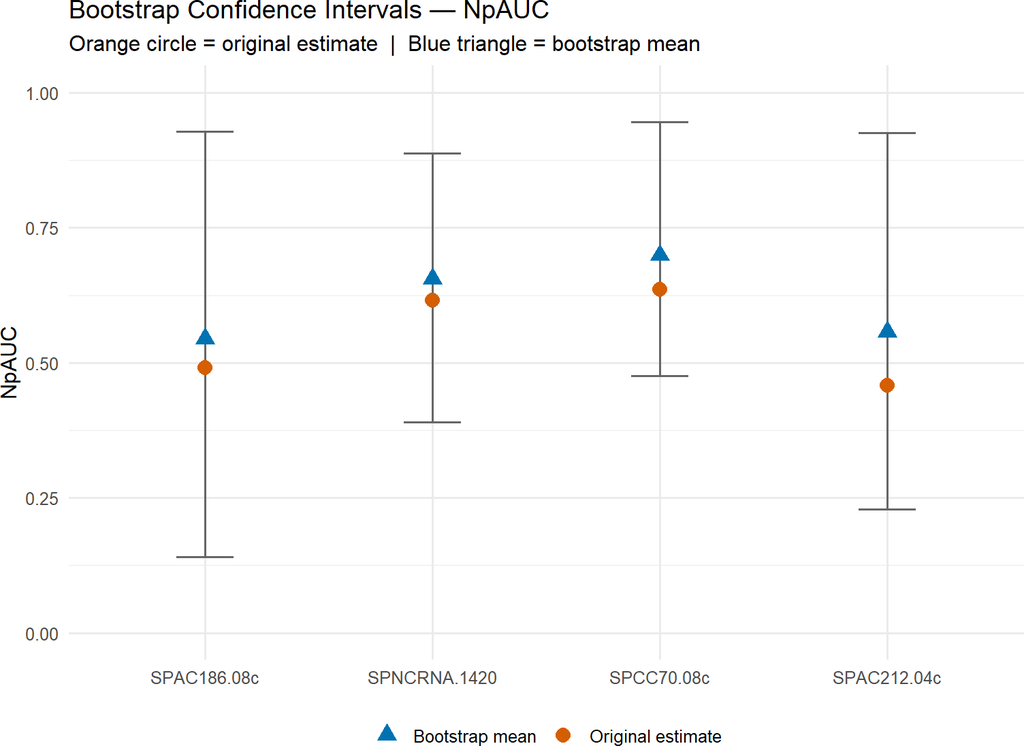

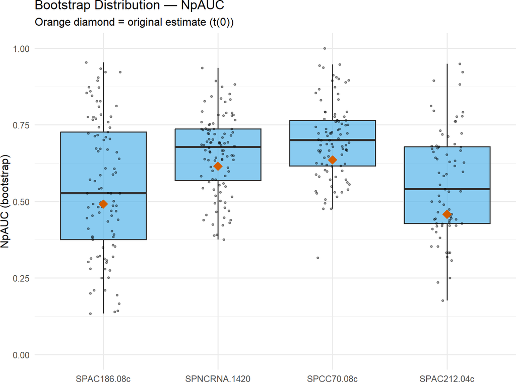

```r
# Input type 1: SummarizedExperiment → Output: tibble (with diagnostic plots)
boot_Np = NpAUCboot(
  fission,
  low.value = 0.9, up.value = 1,
  selection = genes_of_interest, variable = "strain",
  r = 100, plot = TRUE, plot_type = "both"
)
```

```r
boot_Np
```

| Variable | NpAUC | bias | sd | lwr | upr |
| --- | --- | --- | --- | --- | --- |
| SPNCRNA.1080 | NA | NA | NA | NA | NA |
| SPAC186.08c | 0.4913580 | 0.05363158 | 0.2212505 | 0.1412573 | 0.9288128 |
| SPNCRNA.1420 | 0.6154321 | 0.03996452 | 0.1264457 | 0.3897412 | 0.8874648 |
| SPCC70.08c | 0.6358025 | 0.06343290 | 0.1260502 | 0.4761905 | 0.9462286 |
| SPAC212.04c | 0.4580247 | 0.09965737 | 0.1739548 | 0.2283605 | 0.9258302 |

```r
# Input type 2: plain data.frame → Output: tibble
NpAUCboot(Sp, low.value = 0.9, up.value = 1, r = 100)
```

| Variable | NpAUC | bias | sd | lwr | upr |
| --- | --- | --- | --- | --- | --- |
| SPNCRNA.1080 | NA | NA | NA | NA | NA |
| SPAC186.08c | 0.4913580 | 0.03904305 | 0.2062848 | 0.1659039 | 0.8752861 |
| SPNCRNA.1420 | 0.6154321 | 0.01658019 | 0.1165990 | 0.3982831 | 0.8536529 |
| SPCC70.08c | 0.6358025 | 0.03480216 | 0.1206179 | 0.3770175 | 0.8920940 |
| SPAC212.04c | 0.4580247 | 0.08331720 | 0.1845688 | 0.1626781 | 0.8853113 |

## 5.4 FpAUCboot

Estimates confidence intervals for the fitted partial area index (FpAUC) via nonparametric bootstrap resampling. Because FpAUC is valid for any ROC curve shape, no variables are skipped. This makes FpAUCboot the most robust bootstrap function in the package, especially useful when NpAUCboot returns NA for some variables.

### 5.4.1 Demo — FpAUCboot

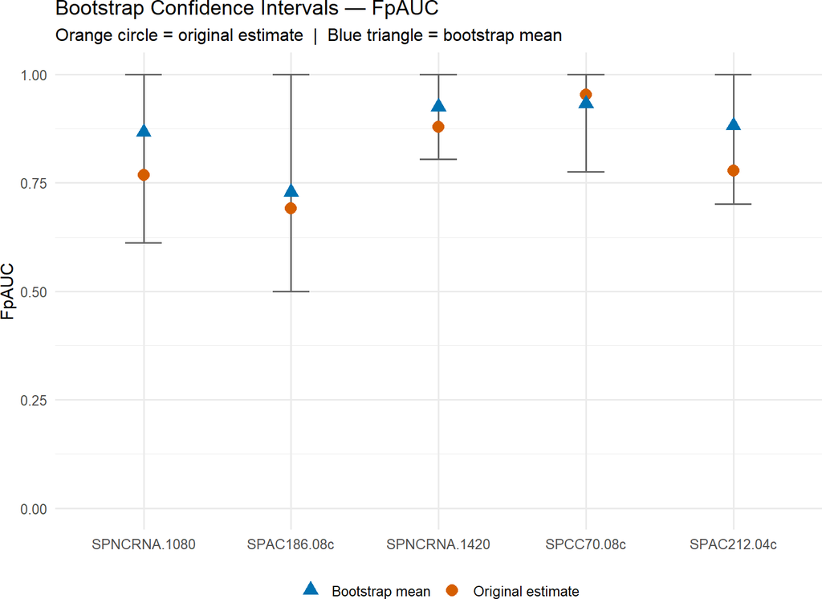

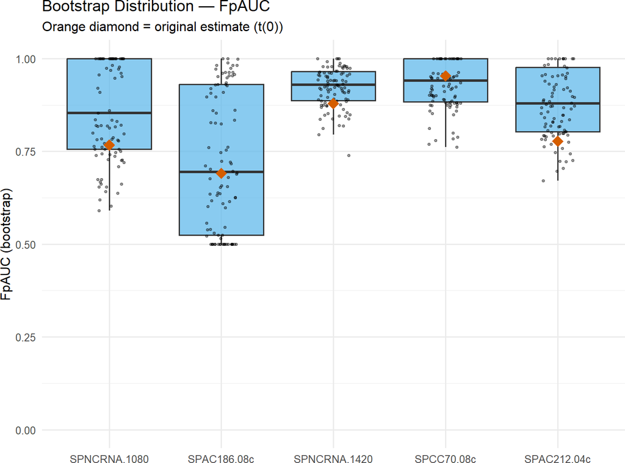

```r
# Input type 1: SummarizedExperiment → Output: tibble (with diagnostic plots)
boot_Fp = FpAUCboot(
  fission,
  low.value = 0.9, up.value = 1,
  selection = genes_of_interest, variable = "strain",
  r = 100, plot = TRUE, plot_type = "both"
)
```

```r
boot_Fp
```

| Variable | FpAUC | bias | sd | lwr | upr |
| --- | --- | --- | --- | --- | --- |
| SPNCRNA.1080 | 0.7675841 | 0.09911741 | 0.13190882 | 0.6124665 | 1 |
| SPAC186.08c | 0.6909722 | 0.03790106 | 0.18928245 | 0.5000000 | 1 |
| SPNCRNA.1420 | 0.8791887 | 0.04584737 | 0.05516468 | 0.8046016 | 1 |
| SPCC70.08c | 0.9537037 | -0.02159108 | 0.06374196 | 0.7753552 | 1 |
| SPAC212.04c | 0.7777778 | 0.10422535 | 0.09218386 | 0.7011265 | 1 |

```r
# Input type 2: SummarizedExperiment → Output: SummarizedExperiment
boot_Fp_se = FpAUCboot(
  fission,
  low.value = 0.9, up.value = 1,
  selection = genes_of_interest, variable = "strain",
  r = 100, output_as_SE = TRUE
)
assay(boot_Fp_se)
```

```
#>       SPNCRNA.1080 SPAC186.08c SPNCRNA.1420   SPCC70.08c SPAC212.04c
#> FpAUC    0.7675841  0.69097222   0.87918871  0.953703704   0.7777778
#> bias     0.1033264  0.04436501   0.05636355 -0.004140607   0.1101353
#> sd       0.1285263  0.17889788   0.05968863  0.063718838   0.0938176
#> lwr      0.6128833  0.50000000   0.79421826  0.804355776   0.6981170
#> upr      1.0000000  1.00000000   1.00000000  1.000000000   1.0000000
```

```r
# Input type 3: plain data.frame → Output: tibble
FpAUCboot(Sp, low.value = 0.9, up.value = 1, r = 100)
```

| Variable | FpAUC | bias | sd | lwr | upr |
| --- | --- | --- | --- | --- | --- |
| SPNCRNA.1080 | 0.7675841 | 0.105003632 | 0.13391991 | 0.5750408 | 1.0000000 |
| SPAC186.08c | 0.6909722 | 0.042028614 | 0.16368032 | 0.5000000 | 0.9930866 |
| SPNCRNA.1420 | 0.8791887 | 0.049042757 | 0.06487321 | 0.7487510 | 1.0000000 |
| SPCC70.08c | 0.9537037 | 0.002133667 | 0.06187332 | 0.7881523 | 1.0000000 |
| SPAC212.04c | 0.7777778 | 0.108819748 | 0.08075843 | 0.7189517 | 1.0000000 |

# 6 Comparative Summary Tables

## 6.1 Point-Estimate Indexes

Combine all four point-estimate tibbles side by side into one summary table. pAUC_FPR = raw FPR-domain pAUC (basis for MCpAUC and TpAUC) pAUC_TPR = raw TPR-domain pAUC (basis for NpAUC and FpAUC)

```r
summary_tbl = res_MC %>%
  dplyr::rename(pAUC_FPR = pAUC) %>%
  dplyr::left_join(
    dplyr::select(res_Tp, Variable, TpAUC),
    by = "Variable"
  ) %>%
  dplyr::left_join(
    dplyr::select(res_Np, Variable, NpAUC, pAUC_TPR = pAUC),
    by = "Variable"
  ) %>%
  dplyr::left_join(
    dplyr::select(res_Fp, Variable, FpAUC),
    by = "Variable"
  ) %>%
  dplyr::select(Variable, pAUC_FPR, MCpAUC, TpAUC, pAUC_TPR, NpAUC, FpAUC)

summary_tbl
```

| Variable | pAUC_FPR | MCpAUC | TpAUC | pAUC_TPR | NpAUC | FpAUC |
| --- | --- | --- | --- | --- | --- | --- |
| SPNCRNA.1080 | 0.05709877 | NA | 0.7569444 | 0.03740741 | NA | 0.7675841 |
| SPAC186.08c | 0.11921296 | NA | 0.7768817 | 0.04913580 | 0.4913580 | 0.6909722 |
| SPNCRNA.1420 | 0.14737654 | 0.7654321 | 0.8278867 | 0.06154321 | 0.6154321 | 0.8791887 |
| SPCC70.08c | 0.16820988 | 0.8130511 | 0.8074074 | 0.06358025 | 0.6358025 | 0.9537037 |
| SPAC212.04c | 0.18055556 | 0.8412698 | 0.8666667 | 0.04580247 | 0.4580247 | 0.7777778 |

## 6.2 Bootstrap Confidence Intervals

Build transposed bootstrap summary tables: genes as columns, metrics as rows. This layout makes it easy to compare the same metric across genes at a glance.

```r
# Build transposed bootstrap summary tables: genes as columns, metrics as rows.
# This layout makes it easy to compare the same metric across genes at a glance.

# Helper: pivot one bootstrap result to a metric × gene matrix
make_boot_matrix = function(boot_tbl, index_col) {
  # Reshape: one row per metric (estimate, bias, sd, lwr, upr), one column per gene
  metrics = c(index_col, "bias", "sd", "lwr", "upr")
  mat = t(as.matrix(boot_tbl[, metrics]))
  colnames(mat) = boot_tbl$Variable
  rownames(mat) = metrics
  return(as.data.frame(round(mat, 6)))
}

# FPR-domain bootstrap summary (MCpAUC and TpAUC) — genes as columns
cat("Bootstrap Summary — MCpAUC (FPR in [0, 0.25])\n")
```

```
#> Bootstrap Summary — MCpAUC (FPR in [0, 0.25])
```

```r
make_boot_matrix(boot_MC, "MCpAUC")
```

|  | SPNCRNA.1080 | SPAC186.08c | SPNCRNA.1420 | SPCC70.08c | SPAC212.04c |
| --- | --- | --- | --- | --- | --- |
| MCpAUC | NA | NA | 0.765432 | 0.813051 | 0.841270 |
| bias | NA | NA | 0.025943 | 0.010524 | -0.001514 |
| sd | NA | NA | 0.083249 | 0.074148 | 0.070508 |
| lwr | NA | NA | 0.623139 | 0.697938 | 0.684610 |
| upr | NA | NA | 0.954824 | 0.983953 | 0.975886 |

```r
cat("Bootstrap Summary — TpAUC (FPR in [0, 0.25])\n")
```

```
#> Bootstrap Summary — TpAUC (FPR in [0, 0.25])
```

```r
make_boot_matrix(boot_Tp, "TpAUC")
```

|  | SPNCRNA.1080 | SPAC186.08c | SPNCRNA.1420 | SPCC70.08c | SPAC212.04c |
| --- | --- | --- | --- | --- | --- |
| TpAUC | 0.756944 | 0.776882 | 0.827887 | 0.807407 | 0.866667 |
| bias | -0.049638 | -0.010904 | -0.013177 | 0.021216 | -0.003215 |
| sd | 0.121074 | 0.129252 | 0.086154 | 0.074038 | 0.079568 |
| lwr | 0.515357 | 0.538917 | 0.657006 | 0.679536 | 0.675103 |
| upr | 0.923394 | 0.961224 | 1.000000 | 1.000000 | 1.000000 |

```r
cat("Bootstrap Summary — NpAUC (TPR in [0.9, 1])\n")
```

```
#> Bootstrap Summary — NpAUC (TPR in [0.9, 1])
```

```r
make_boot_matrix(boot_Np, "NpAUC")
```

|  | SPNCRNA.1080 | SPAC186.08c | SPNCRNA.1420 | SPCC70.08c | SPAC212.04c |
| --- | --- | --- | --- | --- | --- |
| NpAUC | NA | 0.491358 | 0.615432 | 0.635802 | 0.458025 |
| bias | NA | 0.053632 | 0.039965 | 0.063433 | 0.099657 |
| sd | NA | 0.221251 | 0.126446 | 0.126050 | 0.173955 |
| lwr | NA | 0.141257 | 0.389741 | 0.476190 | 0.228361 |
| upr | NA | 0.928813 | 0.887465 | 0.946229 | 0.925830 |

```r
cat("Bootstrap Summary — FpAUC (TPR in [0.9, 1])\n")
```

```
#> Bootstrap Summary — FpAUC (TPR in [0.9, 1])
```

```r
make_boot_matrix(boot_Fp, "FpAUC")
```

|  | SPNCRNA.1080 | SPAC186.08c | SPNCRNA.1420 | SPCC70.08c | SPAC212.04c |
| --- | --- | --- | --- | --- | --- |
| FpAUC | 0.767584 | 0.690972 | 0.879189 | 0.953704 | 0.777778 |
| bias | 0.099117 | 0.037901 | 0.045847 | -0.021591 | 0.104225 |
| sd | 0.131909 | 0.189282 | 0.055165 | 0.063742 | 0.092184 |
| lwr | 0.612466 | 0.500000 | 0.804602 | 0.775355 | 0.701126 |
| upr | 1.000000 | 1.000000 | 1.000000 | 1.000000 | 1.000000 |

# 7 SummarizedExperiment Output Demo

Return MCpAUC results as a SummarizedExperiment for downstream Bioconductor workflows (e.g., integration with DESeq2 or limma

```r
se_MC = MCpAUC(
  fission,
  low.value = 0, up.value = 0.25,
  selection = genes_of_interest, variable = "strain",
  output_as_SE = TRUE
)

# The assay matrix: rows = metrics (MCpAUC and pAUC), columns = predictor variables
assay(se_MC)
```

```
#>        SPNCRNA.1080 SPAC186.08c SPNCRNA.1420 SPCC70.08c SPAC212.04c
#> MCpAUC           NA          NA    0.7654321  0.8130511   0.8412698
#> pAUC     0.05709877    0.119213    0.1473765  0.1682099   0.1805556
```

```r
# Row metadata: names of the computed metrics stored in the assay
rowData(se_MC)
```

```
#> DataFrame with 2 rows and 1 column
#>             metric
#>        <character>
#> MCpAUC      MCpAUC
#> pAUC          pAUC
```

```r
# Column metadata: names of the predictor variables
colData(se_MC)
```

```
#> DataFrame with 5 rows and 1 column
#>                  variable
#>               <character>
#> SPNCRNA.1080 SPNCRNA.1080
#> SPAC186.08c   SPAC186.08c
#> SPNCRNA.1420 SPNCRNA.1420
#> SPCC70.08c     SPCC70.08c
#> SPAC212.04c   SPAC212.04c
```

# 8 References

# Appendix

Alon, U., Barkai, N., Notterman, D. A., Gish, K., Ybarra, S., Mack, D., & Levine, A. J. (1999). Broad patterns of gene expression revealed by clustering analysis of tumor and normal colon tissues probed by oligonucleotide arrays. *Proceedings of the National Academy of Sciences*, *96*(12), 6745–6750. https://doi.org/10.1073/pnas.96.12.6745

Bandos, A. I., Guo, B., & Gur, D. (2017). Estimating the area under ROC curve when the fitted binormal curves demonstrate improper shape. *Academic Radiology*, *24*(2), 209–219. https://doi.org/10.1016/j.acra.2016.09.020

Canty, A., & Ripley, B. D. (2019). *boot: Bootstrap R (S-Plus) functions* (R package version 1.3-24) [Software]. CRAN. https://CRAN.R-project.org/package=boot

Davison, A. C., & Hinkley, D. V. (1997). *Bootstrap methods and their application*. Cambridge University Press. https://doi.org/10.1017/CBO9780511802843

Dudoit, S., Fridlyand, J., & Speed, T. P. (2002). Comparison of discrimination methods for the classification of tumors using gene expression data. *Journal of the American Statistical Association*, *97*(457), 77–87. https://doi.org/10.1198/016214502753479248

Fawcett, T. (2006). An introduction to ROC analysis. *Pattern Recognition Letters*, *27*(8), 861–874. https://doi.org/10.1016/j.patrec.2005.10.010

Franco, M., & Vivo, J.-M. (2021). Evaluating the performances of biomarkers over a restricted domain of high sensitivity. *Mathematics*, *9*(21), 2826. https://doi.org/10.3390/math9212826

García, J.-P., Franco, M., & Vivo, J.-M. (2021). *ROCpAI: Receiver Operating Characteristic Partial Area Indexes for evaluating classifiers* [Bioconductor package]. http://bioconductor.org/packages/ROCpAI/

Golub, T. R., Slonim, D. K., Tamayo, P., Huard, C., Gaasenbeek, M., Mesirov, J. P., Coller, H., Loh, M. L., Downing, J. R., Caligiuri, M. A., Bloomfield, C. D., & Lander, E. S. (1999). Molecular classification of cancer: Class discovery and class prediction by gene expression monitoring. *Science*, *286*(5439), 531–537. https://doi.org/10.1126/science.286.5439.531

Greiner, M., Pfeiffer, D., & Smith, R. D. (2000). Principles and practical application of the receiver-operating characteristic analysis for diagnostic tests. *Preventive Veterinary Medicine*, *45*(1–2), 23–41. https://doi.org/10.1016/S0167-5877(00)00115-X

Jiang, Y., Metz, C. E., & Nishikawa, R. M. (1996). A receiver operating characteristic partial area index for highly sensitive diagnostic tests. *Radiology*, *201*(3), 745–750. https://doi.org/10.1148/radiology.201.3.8939225

Leong, H. S., Dawson, K., Wirth, C., Li, Y., Connolly, Y., Smith, D. L., Wilkinson, C. R. M., & Miller, C. J. (2014). A global non-coding RNA system modulates fission yeast protein levels in response to stress. *Nature Communications*, *5*, 3947. https://doi.org/10.1038/ncomms4947

Marguerat, S., Schmidt, A., Codlin, S., Chen, W., Aebersold, R., & Bähler, J. (2012). Quantitative analysis of fission yeast transcriptomes and proteomes in proliferating and quiescent cells. *Cell*, *151*(3), 671–683. https://doi.org/10.1016/j.cell.2012.09.019

McClish, D. K. (1989). Analyzing a portion of the ROC curve. *Medical Decision Making*, *9*(3), 190–195. https://doi.org/10.1177/0272989X8900900307

Metz, C. E. (1978). Basic principles of ROC analysis. *Seminars in Nuclear Medicine*, *8*(4), 283–298. https://doi.org/10.1016/S0001-2998(78)80014-2

Morgan, M., Obenchain, V., Hester, J., & Pagès, H. (n.d.). *SummarizedExperiment: A container (S4 class) for matrix-like assays* [Bioconductor package]. https://bioconductor.org/packages/SummarizedExperiment

Pepe, M. S., Longton, G., Anderson, G. L., & Schummer, M. (2003). Selecting differentially expressed genes from microarray experiments. *Biometrics*, *59*(1), 133–142. https://doi.org/10.1111/1541-0420.00016

Thompson, M. L., & Zucchini, W. (1989). On the statistical analysis of ROC curves. *Statistics in Medicine*, *8*(10), 1277–1290. https://doi.org/10.1002/sim.4780081011

Vivo, J.-M., Franco, M., & Vicari, D. (2018). Rethinking an ROC partial area index for evaluating the classification performance at a high specificity range. *Advances in Data Analysis and Classification*, *12*(3), 683–704. https://doi.org/10.1007/s11634-017-0295-9